# Histogram

Sanghoo Yoon

- layout에 widths와 heights를 주면 폭과 높이를 조정할 있습니다.

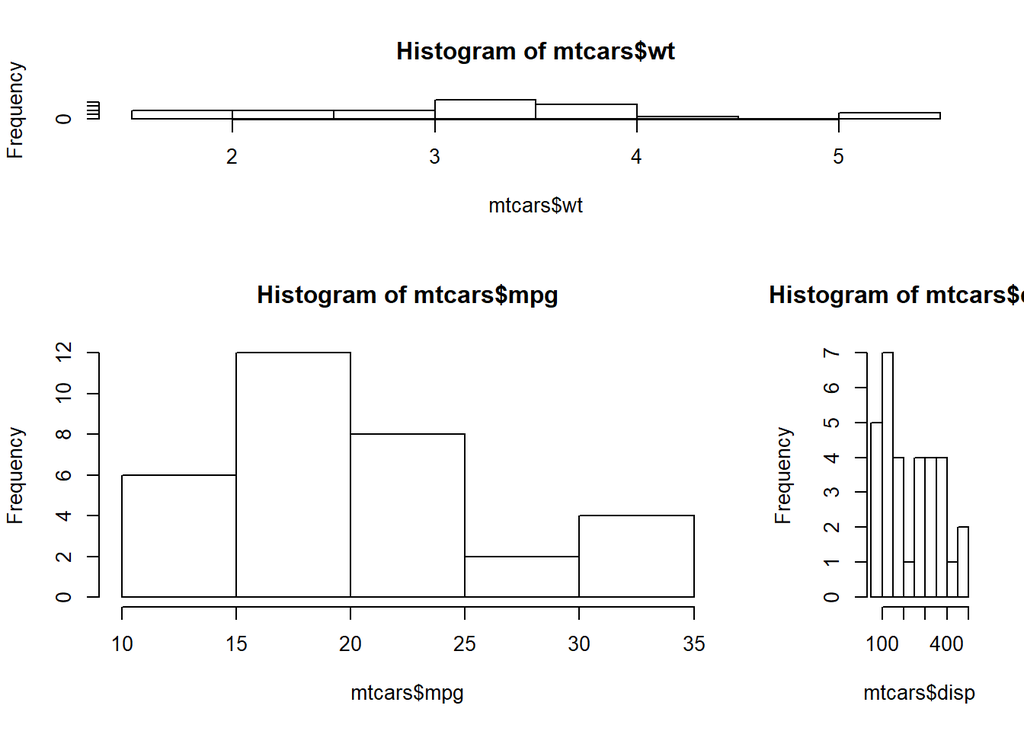

```r
layout(matrix(c(1,1,2,3), 2, 2, byrow = TRUE), widths=c(3,1), heights=c(1,2))
hist(mtcars$wt)
hist(mtcars$mpg)
hist(mtcars$disp)
```

# 히스토 그램

## Simple Histogram

- hist()함수에 숫자로 된 벡터를 넣어주면 된다.

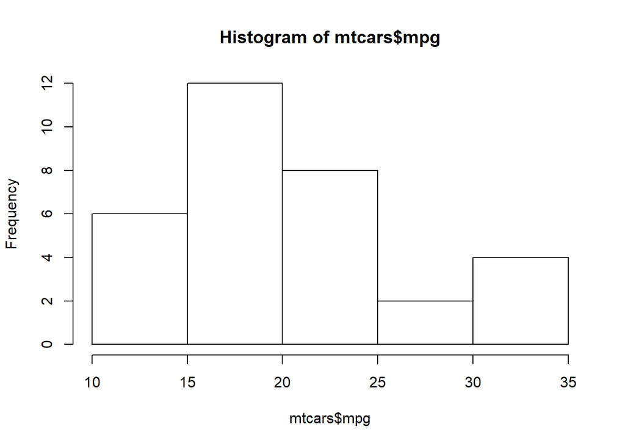

```r
hist(mtcars$mpg)
```

- 만약 원하는 수의 계급으로 나누어 그리고 싶다면 breaks를 넣으면 된다.

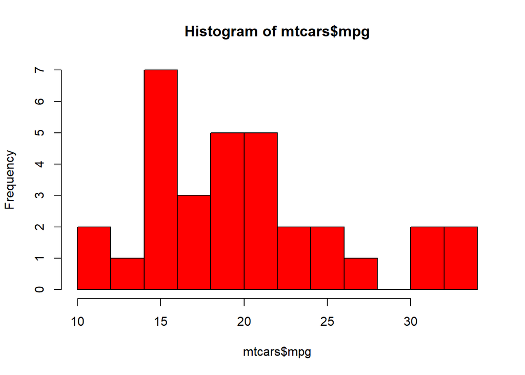

```r
hist(mtcars$mpg, breaks=12, col="red")
```

- Sturges 공식으로 적절한 계급의 수를 구할 수 있다.

```r
class.n <- ceiling(log(length(mtcars$mpg), base = 2) +1 )
class.n
```

```
## [1] 6
```

- 또는, seq()함수의 length.out을 통해 원하는 구간을 등간격으로 만들 수 있다.
- nclass는 breaks와 동일하다.

```r
breaks=seq(min(mtcars$mpg), max(mtcars$mpg), length.out=12)
breaks
```

```
##  [1] 10.40000 12.53636 14.67273 16.80909 18.94545 21.08182 23.21818 25.35455
##  [9] 27.49091 29.62727 31.76364 33.90000
```

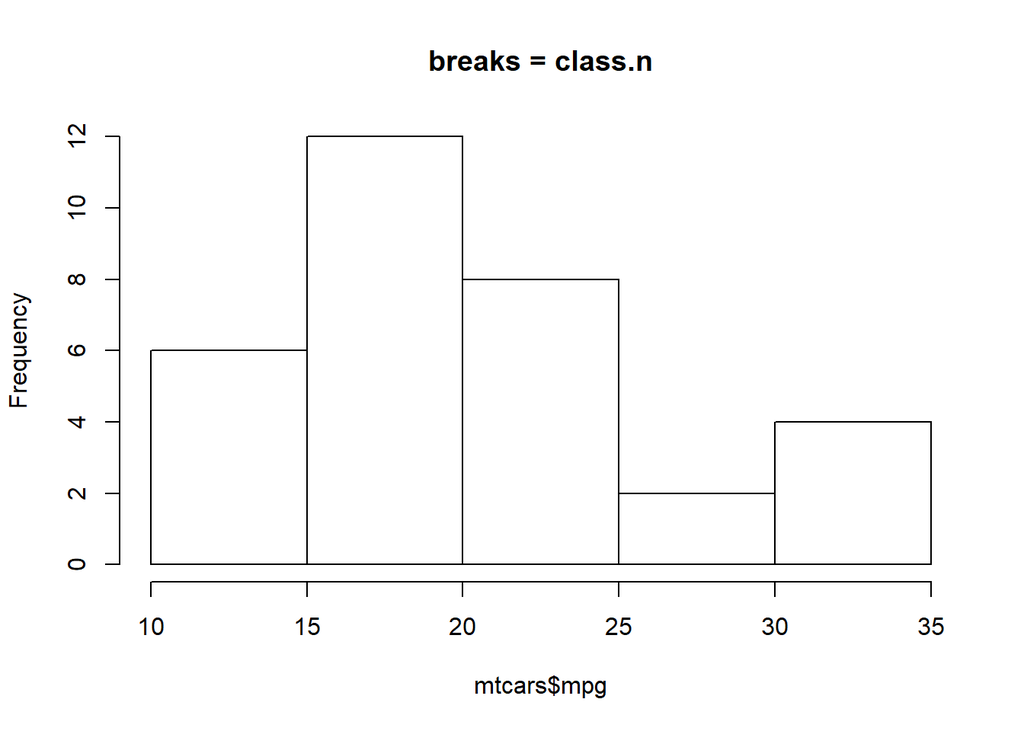

```r
hist(mtcars$mpg, breaks = class.n, main = "breaks = class.n")
```

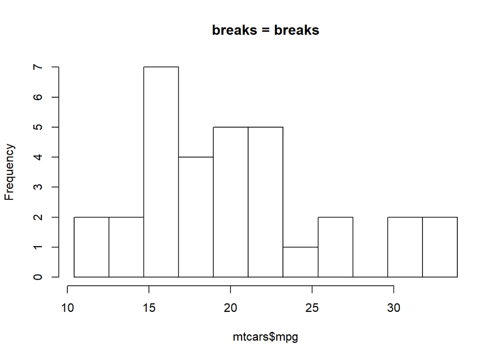

```r
hist(mtcars$mpg, breaks = breaks, main = "breaks = breaks")
```

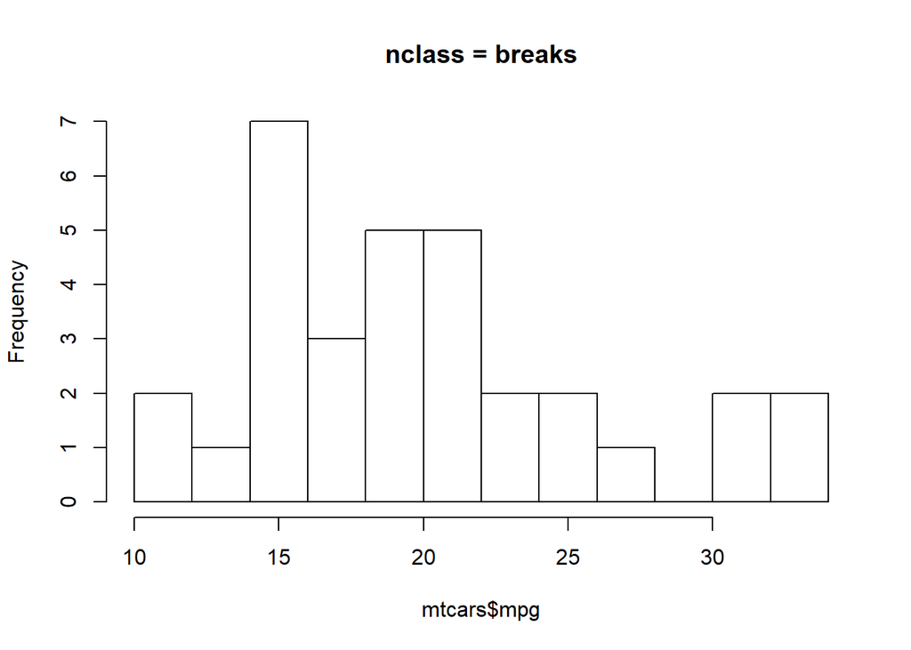

```r
hist(mtcars$mpg, nclass = 14, main = "nclass = breaks")
```

- 만약 도수분포표가 만들고 싶다면?
- 아래의 cut() 함수를 이용하자.
- cut()는 최소값은 포함하지 못하므로 breaks의 최소값을 조금 수정해주자.

```r
breaks[1]=breaks[1]-0.5

freq.mpg<-cut(mtcars$mpg, breaks=breaks)
table(freq.mpg)
```

```
## freq.mpg
##  (9.9,12.5] (12.5,14.7] (14.7,16.8] (16.8,18.9] (18.9,21.1] (21.1,23.2]
##           2           2           7           4           5           5
## (23.2,25.4] (25.4,27.5] (27.5,29.6] (29.6,31.8] (31.8,33.9]
##           1           2           0           2           2
```

- 만약 빈도가 아니라 확률을 그리고 싶다면 probability=TRUE 를 넣어주자.
- 그러면 빈도가 아닌 확률이 히스토그램으로 그려진다.

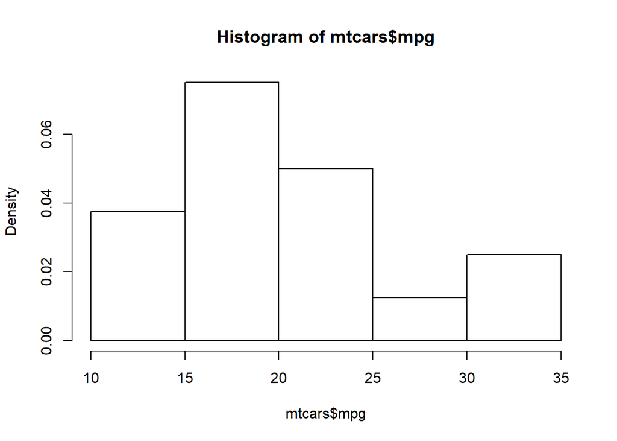

```r
hist(mtcars$mpg, probability=TRUE)
```

## 정규분포선과 히스토그램

- 정규분포를 따르는 자료의 확률을 dnorm()함수를 통해 구할 수 있다.
- 여기서 자료의 평균과 표준편차가 들어간다.
- 이를 hist()와 함께 그리면 히스토그램에서 구한 자료가 정규분포를 따라는지 시각적으로 확인할 수 있다.
- hist에 probability=TRUE를 꼭 표시해야한다.

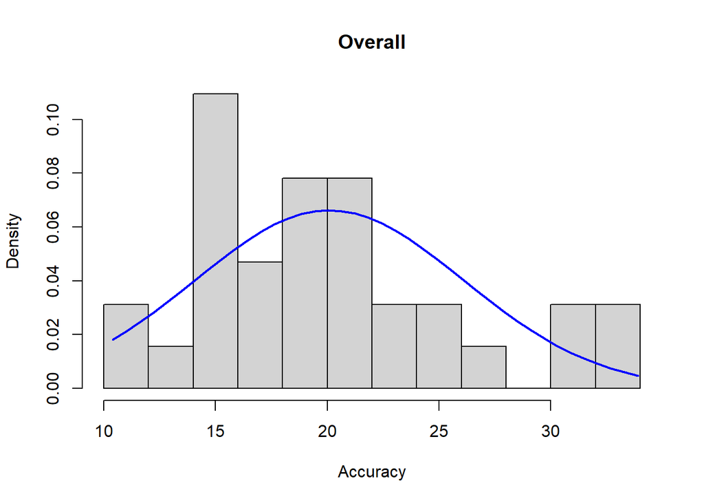

```r
g <- mtcars$mpg
h <- hist(g, breaks = 10, col = "lightgray",
          xlab = "Accuracy", main = "Overall", probability=TRUE)

xfit <- seq(min(g), max(g), length = 40)
yfit <- dnorm(xfit, mean = mean(g), sd = sd(g))

lines(xfit, yfit, col = "blue", lwd = 2)
```

- 빈도에 대해서 그리고 싶다면 yfit 즉 확률값 자료의 숫자인 length()를 곱해주어야 한다.
- 추가로 히스토그램의 계급의 범위는 항상 1일 아니므로 diff(h$mids[1:2])를 통해 계급의 범위를 계산하여 yfit에 추가로 곱해주자.

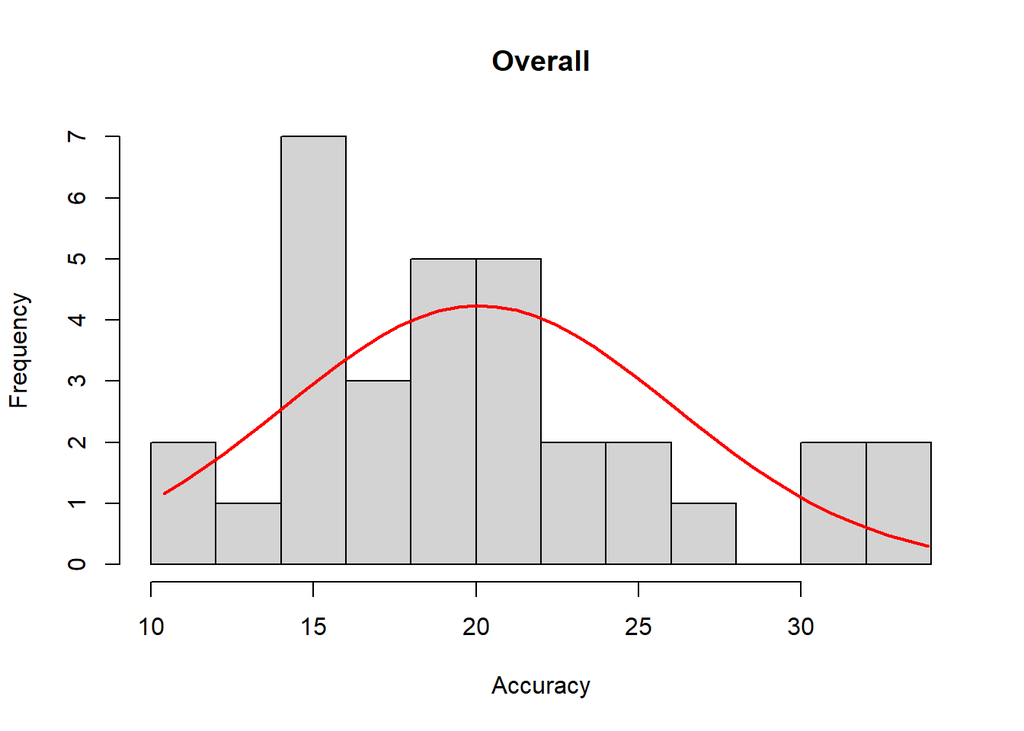

```r
g <- mtcars$mpg
h <- hist(g, breaks = 10,
          col = "lightgray", xlab = "Accuracy", main = "Overall")



xfit <- seq(min(g), max(g), length = 40)
yfit <- dnorm(xfit, mean = mean(g), sd = sd(g))
yfit <- yfit * diff(h$mids[1:2]) * length(g)

lines(xfit, yfit, col = "red", lwd = 2)
```